# PAPER–Lowry-16S-2-R

Jessie Romero

2025-02-21

# 16S rRNA data analysis protocol for Lowry Landfill support media samples (RStudio) (JR, 02.03.2025)

## Based on Orchestrating Microbiome Analysis (OMA) https://microbiome.github.io/OMA/

This rmarkdown file was created, then the rmarkdown package was installed and loaded to edit the file.

Load rmarkdown package.

```r
library(rmarkdown)
```

Install all packages from OMA Github page for 16S rRNA analyses. Only need to run this once throughout entire analyses. NOTE: It takes several minutes to install all packages. Uncomment line, then run code chunk to install packages.

```r
#source("https://raw.githubusercontent.com/microbiome/OMA/master/install_packages.R")
```

Load mia package to analyze QIIME2 16S data files.

```r
library(mia)
```

If not already installed, install matrixStats package needed for mia package. Uncomment then run code chunk to install.

```r
#install.packages("matrixStats")
```

If not already loaded, load matrixStats package.

```r
library(matrixStats)
```

### Upload QIIME2 files.

featureTableFile is the output FeatureTable[Frequency] file from denoising taxonomyTableFile is the output FeatureData[Taxonomy] file from taxonomy classification sampleMetaFile is the metadatafile phyTreeFile is the Phylogeny[Rooted] file All files will be combined into a TreeSummarizedExperiment file names ‘min5300_noChlorMitoUnassigned’.

```r
min5300_noChlorMitoUnassigned <- loadFromQIIME2(
  featureTableFile = 'C:/Users/jessi/Desktop/16S/v2023.5/table_min5300-noChlorMitoUnassigned.qza',
  taxonomyTableFile = 'C:/Users/jessi/Desktop/16S/v2023.5/min5300-noChlorMitoUnassigned_tax-silva-138-99-515-806.qza',
  sampleMetaFile = 'C:/Users/jessi/Desktop/16S/v2023.5/JR_samples_min5300-noChlorMitoUnassigned_metadata.tsv',
  featureNamesAsRefSeq = TRUE, refSeqFile = NULL,
  phyTreeFile = 'C:/Users/jessi/Desktop/16S/v2023.5/rooted-tree_min5300-noChlorMitoUnassigned.qza')
```

### Check that taxonomy information is available in ‘min5300_noChlorMitoUnassigned’ (OMA 6.3)

```r
checkTaxonomy(min5300_noChlorMitoUnassigned)
```

```
## [1] TRUE
```

```r
taxonomyRanks(min5300_noChlorMitoUnassigned)
```

```
## [1] "Kingdom" "Phylum"  "Class"   "Order"   "Family"  "Genus"   "Species"
```

Print some of the taxonomy information (OMA 6.3)

```r
head(rowData(min5300_noChlorMitoUnassigned)[,taxonomyRanks(min5300_noChlorMitoUnassigned)])
```

```
## DataFrame with 6 rows and 7 columns
##                                      Kingdom              Phylum
##                                  <character>         <character>
## bc3676c17839094c4fa8e33268905268          NA    p__Crenarchaeota
## 83eea5d8a1614686968c7853dd6e9826          NA     p__Nitrospirota
## 1d0570a38929afc81b0f046a8874de19          NA   p__Proteobacteria
## e16d86b7fe770de88e7e8fd0fb6c8b5a          NA   p__Proteobacteria
## e02e62f52ae5b6ad31148f0f1639004f          NA p__Actinobacteriota
## e38bafa6321bd4ed4b15f934c3eb652c          NA     p__Nitrospirota
##                                                   Class                 Order
##                                             <character>           <character>
## bc3676c17839094c4fa8e33268905268     c__Nitrososphaeria  o__Nitrososphaerales
## 83eea5d8a1614686968c7853dd6e9826         c__Nitrospiria      o__Nitrospirales
## 1d0570a38929afc81b0f046a8874de19 c__Gammaproteobacteria    o__Burkholderiales
## e16d86b7fe770de88e7e8fd0fb6c8b5a c__Gammaproteobacteria o__Steroidobacterales
## e02e62f52ae5b6ad31148f0f1639004f      c__Actinobacteria  o__Pseudonocardiales
## e38bafa6321bd4ed4b15f934c3eb652c         c__Nitrospiria      o__Nitrospirales
##                                                  Family                  Genus
##                                             <character>            <character>
## bc3676c17839094c4fa8e33268905268  f__Nitrososphaeraceae g__Candidatus_Nitroc..
## 83eea5d8a1614686968c7853dd6e9826      f__Nitrospiraceae          g__Nitrospira
## 1d0570a38929afc81b0f046a8874de19   f__Nitrosomonadaceae              g__mle1-7
## e16d86b7fe770de88e7e8fd0fb6c8b5a f__Steroidobacteraceae      g__Steroidobacter
## e02e62f52ae5b6ad31148f0f1639004f  f__Pseudonocardiaceae      g__Pseudonocardia
## e38bafa6321bd4ed4b15f934c3eb652c      f__Nitrospiraceae          g__Nitrospira
##                                                 Species
##                                             <character>
## bc3676c17839094c4fa8e33268905268                     NA
## 83eea5d8a1614686968c7853dd6e9826                     NA
## 1d0570a38929afc81b0f046a8874de19     s__uncultured_beta
## e16d86b7fe770de88e7e8fd0fb6c8b5a                     NA
## e02e62f52ae5b6ad31148f0f1639004f                     NA
## e38bafa6321bd4ed4b15f934c3eb652c s__Nitrospira_defluvii
```

### Look at the dimensions of ‘min5300_noChlorMitoUnassigned’. Should print the number of ASVs and the number of samples.

```r
dim(min5300_noChlorMitoUnassigned)
```

```
## [1] 884  23
```

Print the sampling date categories in ‘min5300_noChlorMitoUnassigned’

```r
unique(min5300_noChlorMitoUnassigned$sampling_date)
```

```
## [1] "2019-03-26" "2022-01-18" "2022-01-25" "2022-03-22"
```

Load packages to use %>% for subsetting in R

```r
library(dplyr)
library(magrittr)
```

Print the number of samples in each sampling date category as a table

```r
min5300_noChlorMitoUnassigned$sampling_date %>% table()
```

```
## .
## 2019-03-26 2022-01-18 2022-01-25 2022-03-22
##          5          7          6          5
```

### Print the taxa at a given taxonomic level in ‘min5300_noChlorMitoUnassigned’ (e.g., Phylum) (OMA 4.1.2.2)

```r
unique(rowData(min5300_noChlorMitoUnassigned)$Phylum)
```

```
##  [1] "p__Crenarchaeota"                "p__Nitrospirota"
##  [3] "p__Proteobacteria"               "p__Actinobacteriota"
##  [5] "p__Bacteroidota"                 "p__Myxococcota"
##  [7] "p__Acidobacteriota"              "p__Desulfobacterota"
##  [9] "p__Planctomycetota"              "p__Dadabacteria"
## [11] "p__Verrucomicrobiota"            "p__Gemmatimonadota"
## [13] "p__Chloroflexi"                  "p__MBNT15"
## [15] "p__Patescibacteria"              "p__Cyanobacteria"
## [17] NA                                "p__Bdellovibrionota"
## [19] "p__Sumerlaeota"                  "p__SAR324_clade(Marine_group_B)"
## [21] "p__WPS-2"                        "p__Latescibacterota"
## [23] "p__Hydrogenedentes"              "p__RCP2-54"
## [25] "p__Elusimicrobiota"              "p__Dependentiae"
## [27] "p__NB1-j"                        "p__Deinococcota"
## [29] "p__Firmicutes"                   "p__Campilobacterota"
## [31] "p__Sva0485"                      "p__Spirochaetota"
```

Print the taxa and their frequencies at a given taxonomic level (e.g., Phylum) (OMA 4.1.2.2)

```r
rowData(min5300_noChlorMitoUnassigned)$Phylum %>% table()
```

```
## .
##              p__Acidobacteriota             p__Actinobacteriota
##                              35                              75
##                 p__Bacteroidota             p__Bdellovibrionota
##                              39                              36
##             p__Campilobacterota                  p__Chloroflexi
##                               2                              43
##                p__Crenarchaeota                p__Cyanobacteria
##                               5                              14
##                 p__Dadabacteria                 p__Deinococcota
##                               2                               1
##                 p__Dependentiae             p__Desulfobacterota
##                               8                               8
##              p__Elusimicrobiota                   p__Firmicutes
##                               4                               7
##              p__Gemmatimonadota              p__Hydrogenedentes
##                               7                               1
##             p__Latescibacterota                       p__MBNT15
##                               4                               3
##                  p__Myxococcota                        p__NB1-j
##                              42                               2
##                 p__Nitrospirota              p__Patescibacteria
##                               8                              22
##              p__Planctomycetota               p__Proteobacteria
##                              86                             350
##                      p__RCP2-54 p__SAR324_clade(Marine_group_B)
##                               1                               4
##                p__Spirochaetota                  p__Sumerlaeota
##                               1                               2
##                      p__Sva0485            p__Verrucomicrobiota
##                               1                              38
##                        p__WPS-2
##                               4
```

Print the number of families and their frequencies. One family is labeled as “uncultured”, not clear how many taxa this represents. Will remove from later taxa bar plot to avoid confusion.

```r
unique(rowData(min5300_noChlorMitoUnassigned)$Family)
```

```
##   [1] "f__Nitrososphaeraceae"
##   [2] "f__Nitrospiraceae"
##   [3] "f__Nitrosomonadaceae"
##   [4] "f__Steroidobacteraceae"
##   [5] "f__Pseudonocardiaceae"
##   [6] "f__Parvularculaceae"
##   [7] "f__Hyphomicrobiaceae"
##   [8] "f__Saprospiraceae"
##   [9] "f__uncultured"
##  [10] "f__Methyloligellaceae"
##  [11] "f__Amb-16S-1323"
##  [12] "f__Rhodocyclaceae"
##  [13] "f__67-14"
##  [14] "f__Haliangiaceae"
##  [15] "f__Blastocatellaceae"
```

[output cut: 183 more lines]

```r
rowData(min5300_noChlorMitoUnassigned)$Family %>% table()
```

```
## .
##                           f__0319-6G20                                f__1-20
##                                      3                                      3
##                               f__11-24                               f__67-14
##                                      1                                      7
##                                 f__A4b         f__Absconditabacteriales_(SR1)
##                                      2                                      2
##                    f__Acetobacteraceae                     f__Acetobacterales
##                                      5                                      1
##                f__Acidithiobacillaceae                    f__Alteromonadaceae
##                                      1                                      1
##                        f__Amb-16S-1323                     f__Amoebophilaceae
##                                      2                                      2
##                     f__Arcobacteraceae       f__Azospirillales_Incertae_Sedis
##                                      2                                      3
##                         f__Bacillaceae                  f__Bacteriovoracaceae
##                                      1                                      2
##            f__BD2-11_terrestrial_group                              f__BD7-11
##                                      1                                      6
##                  f__Bdellovibrionaceae                    f__Beijerinckiaceae
##                                     27                                      3
##                             f__BIrii41                   f__Blastocatellaceae
##                                      2                                      6
##                             f__Blfdi19                     f__Bryobacteraceae
##                                      2                                      2
##                    f__Burkholderiaceae                  f__Caenarcaniphilales
##                                      4                                      4
##                      f__Caldilineaceae          f__Candidatus_Abawacabacteria
##                                      2                                      1
##             f__Candidatus_Azambacteria         f__Candidatus_Campbellbacteria
##                                      1                                      1
##           f__Candidatus_Kaiserbacteria            f__Candidatus_Moranbacteria
##                                      2                                      2
##           f__Candidatus_Nomurabacteria             f__Candidatus_Peribacteria
##                                      1                                      1
##              f__Candidatus_Uhrbacteria                    f__Caulobacteraceae
##                                      1                                      7
##                              f__CCM11a                              f__CCM19a
##                                      1                                      1
##                    f__Chitinophagaceae                       f__Chlamydiaceae
```

[output cut: 144 more lines]

```
##                                      3                                      1
##                            f__UBA12409                          f__uncultured
##                                      3                                     54
##                      f__Unknown_Family                 f__Vampirovibrionaceae
##                                      3                                      1
##                  f__Vampirovibrionales                      f__Vermiphilaceae
##                                      4                                      4
##                 f__Verrucomicrobiaceae                           f__VHS-B3-70
##                                      4                                      1
##                 f__Vicinamibacteraceae                               f__WPS-2
##                                      6                                      4
##                   f__Xanthobacteraceae                    f__Xanthomonadaceae
##                                     16                                      4
##                        f__Yersiniaceae
##                                      1
```

### Get relative abundances

```r
min5300_noChlorMitoUnassigned <- transformCounts(min5300_noChlorMitoUnassigned, method = c("relabundance"))
```

Print out relative abundance values (phyla level)

```r
min5300_noChlorMitoUnassigned_phy <- agglomerateByRank(min5300_noChlorMitoUnassigned, rank ="Phylum", onRankOnly=TRUE)

min5300_noChlorMitoUnassigned_phy_RELABUNDANCE <- transformCounts(min5300_noChlorMitoUnassigned_phy, method = "relabundance")

head(assay(min5300_noChlorMitoUnassigned_phy_RELABUNDANCE, "relabundance"))
```

```
##                     19-03-26-R1-N1-A 19-03-26-R1-N1-B 19-03-26-R1-N1-C
## p__Crenarchaeota          0.13039107       0.15475571       0.15656409
## p__Nitrospirota           0.18348390       0.17173031       0.18103629
## p__Proteobacteria         0.36711786       0.36146083       0.34130072
## p__Actinobacteriota       0.14203608       0.13150111       0.17549579
## p__Bacteroidota           0.02627630       0.02785499       0.02726245
## p__Myxococcota            0.02894745       0.02454777       0.01501135
##                     19-03-26-R1-N1-D 19-03-26-R1-N2-C 22-01-18-R1-N1-B
## p__Crenarchaeota          0.13838023       0.14888802       0.04713195
## p__Nitrospirota           0.12066399       0.09105684       0.11346290
## p__Proteobacteria         0.40300729       0.41749131       0.53371626
## p__Actinobacteriota       0.17046300       0.09990331       0.05492171
## p__Bacteroidota           0.02724431       0.04447919       0.04201747
## p__Myxococcota            0.01570642       0.04046742       0.02502164
##                     22-01-18-R1-N1-C 22-01-18-R1-N1-D 22-01-18-R1-N2-A
## p__Crenarchaeota          0.07370593       0.07994407       0.05554107
## p__Nitrospirota           0.20498875       0.07374308       0.18557149
## p__Proteobacteria         0.43360840       0.53516931       0.44902216
## p__Actinobacteriota       0.10221305       0.05538331       0.11069100
## p__Bacteroidota           0.02325581       0.03653718       0.03042156
## p__Myxococcota            0.01200300       0.01848137       0.01355932
##                     22-01-18-R1-N2-B 22-01-18-R1-N2-C 22-01-18-R1-N2-D
## p__Crenarchaeota          0.07223188       0.06889578       0.05311032
## p__Nitrospirota           0.16208696       0.18403667       0.17139635
## p__Proteobacteria         0.45008696       0.46312525       0.44920128
## p__Actinobacteriota       0.11524638       0.08938924       0.12561549
## p__Bacteroidota           0.03965217       0.02844816       0.02758880
## p__Myxococcota            0.01542029       0.01563975       0.01533546
##                     22-01-25-R1-N1-A 22-01-25-R1-N1-B 22-01-25-R1-N1-D
## p__Crenarchaeota          0.06197984       0.07731258       0.05161887
## p__Nitrospirota           0.20669312       0.19241233       0.12534690
## p__Proteobacteria         0.42557151       0.42835550       0.53478261
## p__Actinobacteriota       0.11967553       0.12205260       0.05929695
## p__Bacteroidota           0.01966499       0.02297461       0.03783534
## p__Myxococcota            0.01369526       0.01791112       0.02201665
##                     22-01-25-R1-N2-A 22-01-25-R1-N2-B 22-01-25-R1-N2-D
## p__Crenarchaeota          0.12052148      0.090580680       0.14657880
## p__Nitrospirota           0.18589383      0.238560343       0.17494723
## p__Proteobacteria         0.39589195      0.395236821       0.34968851
## p__Actinobacteriota       0.09923091      0.099411292       0.11285589
## p__Bacteroidota           0.02250985      0.018330211       0.01915255
## p__Myxococcota            0.01078597      0.009098207       0.01240797
##                     22-03-22-R1-N1-B 22-03-22-R1-N1-C 22-03-22-R1-N1-D
## p__Crenarchaeota          0.06688242      0.063165906       0.06726413
## p__Nitrospirota           0.20300701      0.177016743       0.17195194
## p__Proteobacteria         0.42077940      0.424961948       0.43972819
## p__Actinobacteriota       0.11805556      0.159665145       0.10321056
## p__Bacteroidota           0.02669903      0.021613394       0.03023439
## p__Myxococcota            0.01368662      0.008828006       0.01487099
##                     22-03-22-R1-N2-B 22-03-22-R1-N2-D
## p__Crenarchaeota          0.05096694       0.04992355
## p__Nitrospirota           0.13489568       0.14793578
## p__Proteobacteria         0.50804992       0.47759939
## p__Actinobacteriota       0.06687625       0.07614679
## p__Bacteroidota           0.03229494       0.02790520
## p__Myxococcota            0.01962465       0.02232416
```

```r
# Save relative abundance values as a dataframe
df.min5300_noChlorMitoUnassigned_phy_RELABUNDANCE <- as.data.frame((assay(min5300_noChlorMitoUnassigned_phy_RELABUNDANCE, "relabundance")))

# Create a tsv file of relative abundance values
write.table(df.min5300_noChlorMitoUnassigned_phy_RELABUNDANCE, file='min5300_noChlorMitoUnassigned_phy_REL.tsv', quote=FALSE, sep='\t', col.names = NA)
```

Print out relative abundance values (family level). Run agglomerateByRank and set ‘onRankOnly’ parameter to ‘FALSE’ to see full taxonomy string and avoid confusion with multiple “uncultured” families.

```r
min5300_noChlorMitoUnassigned_fam_FALSE <- agglomerateByRank(min5300_noChlorMitoUnassigned, rank ="Family", onRankOnly=FALSE)
min5300_noChlorMitoUnassigned_fam_FALSE_RELABUNDANCE <- transformCounts(min5300_noChlorMitoUnassigned_fam_FALSE, method = "relabundance")

head(assay(min5300_noChlorMitoUnassigned_fam_FALSE_RELABUNDANCE, "relabundance"))
```

```
##                                                                                          19-03-26-R1-N1-A
## NA_p__Crenarchaeota_c__Nitrososphaeria_o__Nitrososphaerales_f__Nitrososphaeraceae              0.13029917
## NA_p__Nitrospirota_c__Nitrospiria_o__Nitrospirales_f__Nitrospiraceae                           0.18335458
## NA_p__Proteobacteria_c__Gammaproteobacteria_o__Burkholderiales_f__Nitrosomonadaceae            0.07165030
## NA_p__Proteobacteria_c__Gammaproteobacteria_o__Steroidobacterales_f__Steroidobacteraceae       0.04393792
## NA_p__Actinobacteriota_c__Actinobacteria_o__Pseudonocardiales_f__Pseudonocardiaceae            0.06118317
## NA_p__Proteobacteria_c__Alphaproteobacteria_o__Caulobacterales_f__Parvularculaceae             0.02637775
##                                                                                          19-03-26-R1-N1-B
## NA_p__Crenarchaeota_c__Nitrososphaeria_o__Nitrososphaerales_f__Nitrososphaeraceae              0.15463963
## NA_p__Nitrospirota_c__Nitrospiria_o__Nitrospirales_f__Nitrospiraceae                           0.17160150
## NA_p__Proteobacteria_c__Gammaproteobacteria_o__Burkholderiales_f__Nitrosomonadaceae            0.07848947
## NA_p__Proteobacteria_c__Gammaproteobacteria_o__Steroidobacterales_f__Steroidobacteraceae       0.04470684
## NA_p__Actinobacteriota_c__Actinobacteria_o__Pseudonocardiales_f__Pseudonocardiaceae            0.05390814
## NA_p__Proteobacteria_c__Alphaproteobacteria_o__Caulobacterales_f__Parvularculaceae             0.02815343
##                                                                                          19-03-26-R1-N1-C
## NA_p__Crenarchaeota_c__Nitrososphaeria_o__Nitrososphaerales_f__Nitrososphaeraceae              0.15645613
## NA_p__Nitrospirota_c__Nitrospiria_o__Nitrospirales_f__Nitrospiraceae                           0.18091145
## NA_p__Proteobacteria_c__Gammaproteobacteria_o__Burkholderiales_f__Nitrosomonadaceae            0.05110933
## NA_p__Proteobacteria_c__Gammaproteobacteria_o__Steroidobacterales_f__Steroidobacteraceae       0.03435938
## NA_p__Actinobacteriota_c__Actinobacteria_o__Pseudonocardiales_f__Pseudonocardiaceae            0.07198681
## NA_p__Proteobacteria_c__Alphaproteobacteria_o__Caulobacterales_f__Parvularculaceae             0.01896862
##                                                                                          19-03-26-R1-N1-D
## NA_p__Crenarchaeota_c__Nitrososphaeria_o__Nitrososphaerales_f__Nitrososphaeraceae              0.13815398
## NA_p__Nitrospirota_c__Nitrospiria_o__Nitrospirales_f__Nitrospiraceae                           0.12046671
## NA_p__Proteobacteria_c__Gammaproteobacteria_o__Burkholderiales_f__Nitrosomonadaceae            0.04763674
## NA_p__Proteobacteria_c__Gammaproteobacteria_o__Steroidobacterales_f__Steroidobacteraceae       0.05179845
## NA_p__Actinobacteriota_c__Actinobacteria_o__Pseudonocardiales_f__Pseudonocardiaceae            0.08405172
## NA_p__Proteobacteria_c__Alphaproteobacteria_o__Caulobacterales_f__Parvularculaceae             0.03589477
##                                                                                          19-03-26-R1-N2-C
## NA_p__Crenarchaeota_c__Nitrososphaeria_o__Nitrososphaerales_f__Nitrososphaeraceae              0.14871363
## NA_p__Nitrospirota_c__Nitrospiria_o__Nitrospirales_f__Nitrospiraceae                           0.09095019
## NA_p__Proteobacteria_c__Gammaproteobacteria_o__Burkholderiales_f__Nitrosomonadaceae            0.09699162
## NA_p__Proteobacteria_c__Gammaproteobacteria_o__Steroidobacterales_f__Steroidobacteraceae       0.04549564
## NA_p__Actinobacteriota_c__Actinobacteria_o__Pseudonocardiales_f__Pseudonocardiaceae            0.03423475
## NA_p__Proteobacteria_c__Alphaproteobacteria_o__Caulobacterales_f__Parvularculaceae             0.03435805
##                                                                                          22-01-18-R1-N1-B
## NA_p__Crenarchaeota_c__Nitrososphaeria_o__Nitrososphaerales_f__Nitrososphaeraceae              0.04624413
## NA_p__Nitrospirota_c__Nitrospiria_o__Nitrospirales_f__Nitrospiraceae                           0.11283255
## NA_p__Proteobacteria_c__Gammaproteobacteria_o__Burkholderiales_f__Nitrosomonadaceae            0.13239437
## NA_p__Proteobacteria_c__Gammaproteobacteria_o__Steroidobacterales_f__Steroidobacteraceae       0.04921753
```

[output cut: 106 more lines]

```
## NA_p__Proteobacteria_c__Alphaproteobacteria_o__Caulobacterales_f__Parvularculaceae             0.04465772
##                                                                                          22-03-22-R1-N2-B
## NA_p__Crenarchaeota_c__Nitrososphaeria_o__Nitrososphaerales_f__Nitrososphaeraceae              0.05074457
## NA_p__Nitrospirota_c__Nitrospiria_o__Nitrospirales_f__Nitrospiraceae                           0.13430712
## NA_p__Proteobacteria_c__Gammaproteobacteria_o__Burkholderiales_f__Nitrosomonadaceae            0.08157071
## NA_p__Proteobacteria_c__Gammaproteobacteria_o__Steroidobacterales_f__Steroidobacteraceae       0.05121882
## NA_p__Actinobacteriota_c__Actinobacteria_o__Pseudonocardiales_f__Pseudonocardiaceae            0.03006734
## NA_p__Proteobacteria_c__Alphaproteobacteria_o__Caulobacterales_f__Parvularculaceae             0.05880679
##                                                                                          22-03-22-R1-N2-D
## NA_p__Crenarchaeota_c__Nitrososphaeria_o__Nitrososphaerales_f__Nitrososphaeraceae              0.04976755
## NA_p__Nitrospirota_c__Nitrospiria_o__Nitrospirales_f__Nitrospiraceae                           0.14747352
## NA_p__Proteobacteria_c__Gammaproteobacteria_o__Burkholderiales_f__Nitrosomonadaceae            0.07743312
## NA_p__Proteobacteria_c__Gammaproteobacteria_o__Steroidobacterales_f__Steroidobacteraceae       0.04229861
## NA_p__Actinobacteriota_c__Actinobacteria_o__Pseudonocardiales_f__Pseudonocardiaceae            0.03345782
## NA_p__Proteobacteria_c__Alphaproteobacteria_o__Caulobacterales_f__Parvularculaceae             0.05937047
```

```r
df.min5300_noChlorMitoUnassigned_fam_FALSE_RELABUNDANCE <- as.data.frame((assay(min5300_noChlorMitoUnassigned_fam_FALSE_RELABUNDANCE, "relabundance")))

write.table(df.min5300_noChlorMitoUnassigned_fam_FALSE_RELABUNDANCE, file='min5300_noChlorMitoUnassigned_fam_FALSE_REL.tsv', quote=FALSE, sep='\t', col.names = NA)
```

Before making plots, edit data to shorten taxonomic labels (e.g., remove “p__” in front of phyla labels)

Load packages to edit data

```r
library(BiocParallel)
library(stringr)
library(S4Vectors)
library(stats4)
library(BiocGenerics)
```

Edit ‘min5300_noChlorMitoUnassigned’ to shorten taxa labels (from https://github.com/microbiome/OMA/blob/master/04_containers.Rmd)

```r
rowdata_edit <- BiocParallel::bplapply(rowData(min5300_noChlorMitoUnassigned),
  FUN = stringr::str_remove, pattern = '.*[kpcofgs]__')
rowdata_edit <- DataFrame(rowdata_edit)

rowData(min5300_noChlorMitoUnassigned) <- rowdata_edit
```

Check that extra labels were removed

```r
head(rowData(min5300_noChlorMitoUnassigned)[,taxonomyRanks(min5300_noChlorMitoUnassigned)])
```

```
## DataFrame with 6 rows and 7 columns
##                                      Kingdom           Phylum
##                                  <character>      <character>
## bc3676c17839094c4fa8e33268905268          NA    Crenarchaeota
## 83eea5d8a1614686968c7853dd6e9826          NA     Nitrospirota
## 1d0570a38929afc81b0f046a8874de19          NA   Proteobacteria
## e16d86b7fe770de88e7e8fd0fb6c8b5a          NA   Proteobacteria
## e02e62f52ae5b6ad31148f0f1639004f          NA Actinobacteriota
## e38bafa6321bd4ed4b15f934c3eb652c          NA     Nitrospirota
##                                                Class              Order
##                                          <character>        <character>
## bc3676c17839094c4fa8e33268905268     Nitrososphaeria  Nitrososphaerales
## 83eea5d8a1614686968c7853dd6e9826         Nitrospiria      Nitrospirales
## 1d0570a38929afc81b0f046a8874de19 Gammaproteobacteria    Burkholderiales
## e16d86b7fe770de88e7e8fd0fb6c8b5a Gammaproteobacteria Steroidobacterales
## e02e62f52ae5b6ad31148f0f1639004f      Actinobacteria  Pseudonocardiales
## e38bafa6321bd4ed4b15f934c3eb652c         Nitrospiria      Nitrospirales
##                                               Family                  Genus
##                                          <character>            <character>
## bc3676c17839094c4fa8e33268905268  Nitrososphaeraceae Candidatus_Nitrocosm..
## 83eea5d8a1614686968c7853dd6e9826      Nitrospiraceae             Nitrospira
## 1d0570a38929afc81b0f046a8874de19   Nitrosomonadaceae                 mle1-7
## e16d86b7fe770de88e7e8fd0fb6c8b5a Steroidobacteraceae         Steroidobacter
## e02e62f52ae5b6ad31148f0f1639004f  Pseudonocardiaceae         Pseudonocardia
## e38bafa6321bd4ed4b15f934c3eb652c      Nitrospiraceae             Nitrospira
##                                              Species
##                                          <character>
## bc3676c17839094c4fa8e33268905268                  NA
## 83eea5d8a1614686968c7853dd6e9826                  NA
## 1d0570a38929afc81b0f046a8874de19     uncultured_beta
## e16d86b7fe770de88e7e8fd0fb6c8b5a                  NA
## e02e62f52ae5b6ad31148f0f1639004f                  NA
## e38bafa6321bd4ed4b15f934c3eb652c Nitrospira_defluvii
```

### ALPHA DIVERSITY

Load packages to create and arrange alpha diversity plots

```r
library(mia)
library(scater)
library(patchwork)
library(scuttle)
```

Estimate observed richness in ‘min5300_noChlorMitoUnassigned’ (OMA 7.1)

```r
min5300_noChlorMitoUnassigned <- mia::estimateRichness(min5300_noChlorMitoUnassigned,
  assay.type = "counts", index = "observed", name="observed")
```

Estimate Shannon diversity

```r
min5300_noChlorMitoUnassigned <- mia::estimateDiversity(min5300_noChlorMitoUnassigned,
  assay.type = "counts", index = "shannon", name = "shannon")
```

Estimate Faith phylogenetic diversity

```r
min5300_noChlorMitoUnassigned <- mia::estimateDiversity(min5300_noChlorMitoUnassigned,
  assay.type = "counts", index = "faith", name = "faith")
```

Estimate evenness (simpson) diversity

```r
min5300_noChlorMitoUnassigned <- estimateEvenness(min5300_noChlorMitoUnassigned,
  assay.type = "counts", index="simpson", name = "simpson")
```

Create a combined alpha diversity plot

Load packages

```r
library(mia)
library(scater)
```

Create an observed richness alpha diversity plot

```r
obs_min5300_noChlorMitoUnassigned <- plotColData(min5300_noChlorMitoUnassigned, "observed", x = "sampling_date",
  colour_by = "sampling_date", shape_by = "support_media_number") +
  scale_color_manual(values = c("2019-03-26" = "#1368c1", "2022-01-18" = "#ff7700", "2022-01-25" = "#17b304", "2022-03-22" = "#f0160a")) +
  theme(axis.text.x = element_blank(),
  axis.title.x = element_blank(),
  axis.ticks.x = element_blank()) +
  guides(color = guide_legend(title = "date", order = 1),
         shape = guide_legend(title = "support media number", order = 2))
```

Create a Shannon metric alpha diversity plot

```r
sh_min5300_noChlorMitoUnassigned <- plotColData(min5300_noChlorMitoUnassigned, "shannon", x = "sampling_date",
  colour_by = "sampling_date", shape_by = "support_media_number") +
  scale_color_manual(values = c("2019-03-26" = "#1368c1", "2022-01-18" = "#ff7700", "2022-01-25" = "#17b304", "2022-03-22" = "#f0160a")) +
  theme(axis.text.x = element_blank(),
  axis.title.x = element_blank(),
  axis.ticks.x = element_blank()) +
  guides(color = guide_legend(title = "date", order = 1),
         shape = guide_legend(title = "support media number", order = 2))
```

Create a Simpson metric alpha diversity plot

```r
s_min5300_noChlorMitoUnassigned <- plotColData(min5300_noChlorMitoUnassigned, "simpson", x = "sampling_date",
  colour_by = "sampling_date", shape_by = "support_media_number") +
  scale_color_manual(values = c("2019-03-26" = "#1368c1", "2022-01-18" = "#ff7700", "2022-01-25" = "#17b304", "2022-03-22" = "#f0160a")) +
  theme(axis.text.x = element_blank(),
  axis.title.x = element_blank(),
  axis.ticks.x = element_blank()) +
  guides(color = guide_legend(title = "date", order = 1),
         shape = guide_legend(title = "support media number", order = 2))
```

Create a Faith PD metric alpha diversity plot

```r
fpd_min5300_noChlorMitoUnassigned <- plotColData(min5300_noChlorMitoUnassigned, "faith", x = "sampling_date",
  colour_by = "sampling_date", shape_by = "support_media_number") +
  scale_color_manual(values = c("2019-03-26" = "#1368c1", "2022-01-18" = "#ff7700", "2022-01-25" = "#17b304", "2022-03-22" = "#f0160a")) +
  theme(axis.text.x = element_blank(),
  axis.title.x = element_blank(),
  axis.ticks.x = element_blank()) +
  guides(color = guide_legend(title = "date", order = 1),
         shape = guide_legend(title = "support media number", order = 2))
```

Combine plots

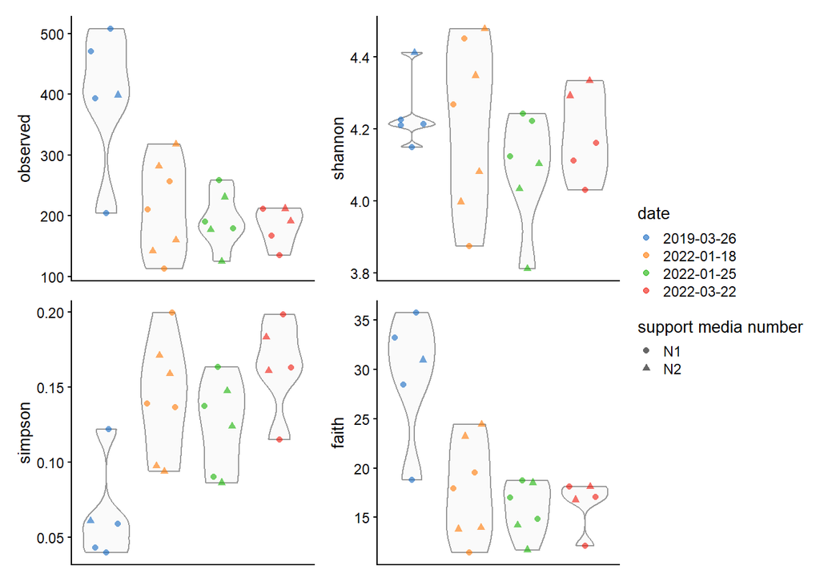

```r
library(patchwork)

obs_min5300_noChlorMitoUnassigned + sh_min5300_noChlorMitoUnassigned + s_min5300_noChlorMitoUnassigned + fpd_min5300_noChlorMitoUnassigned +
  plot_layout(guides = "collect")
```

Create and download an svg image file of the plot

```r
svg('min5300_noChlorMitoUnassigned_alpha.svg')

library(patchwork)

obs_min5300_noChlorMitoUnassigned + sh_min5300_noChlorMitoUnassigned + s_min5300_noChlorMitoUnassigned + fpd_min5300_noChlorMitoUnassigned +
  plot_layout(guides = "collect")

dev.off()
```

Print alpha diversity values and save in a tsv file

```r
df.min5300_noChlorMitoUnassigned_alpha <- as.data.frame(colData(min5300_noChlorMitoUnassigned))
write.table(df.min5300_noChlorMitoUnassigned_alpha, file='df.min5300_noChlorMitoUnassigned_alpha.tsv', quote=FALSE, sep='\t', col.names = NA)
```

### BETA DIVERSITY

Load package

```r
library(mia)
```

Weighted and unweighted NMDS unifrac for ‘min5300_noChlorMitoUnassigned’

Make a phyloseq object from ‘min5300_noChlorMitoUnassigned’ for beta diversity analysis

```r
ps.min5300_noChlorMitoUnassigned <- makePhyloseqFromTreeSE(min5300_noChlorMitoUnassigned)
```

Load packages for NMDS analyses

```r
library(phyloseq)
```

```r
library(ggplot2)
```

Unweighted NMDS analysis

```r
ps.min5300_noChlorMitoUnassigned.uw.NMDS.uni = ordinate(ps.min5300_noChlorMitoUnassigned, method="NMDS", distance="unifrac", weighted=FALSE)
```

```
## *** Best solution repeated 1 times
```

Weighted NMDS analysis

```r
ps.min5300_noChlorMitoUnassigned.w.NMDS.uni = ordinate(ps.min5300_noChlorMitoUnassigned, method="NMDS", distance="unifrac", weighted=TRUE)
```

```
## *** Best solution repeated 9 times
```

Create a combined unweighted and weighted NMDS figure (edit legend labels and plot colors)

Created an unweighted plot

```r
uw_min5300_noChlorMitoUnassigned <- plot_ordination(ps.min5300_noChlorMitoUnassigned, ps.min5300_noChlorMitoUnassigned.uw.NMDS.uni, type = "samples", color = "sampling_date", shape = "support_media_number") +
    theme_bw() +
    ggtitle("Unweighted UniFrac") +
  scale_color_manual(values = c("2019-03-26" = "#1368c1", "2022-01-18" = "#ff7700", "2022-01-25" = "#17b304", "2022-03-22" = "#f0160a")) +
  guides(color = guide_legend(title = "date", order = 1), shape = guide_legend(title = "support media number", order = 2))
```

Create a weighted plot

```r
w_min5300_noChlorMitoUnassigned <- plot_ordination(ps.min5300_noChlorMitoUnassigned, ps.min5300_noChlorMitoUnassigned.w.NMDS.uni, type = "samples", color = "sampling_date", shape = "support_media_number") +
    theme_bw() +
    ggtitle("Weighted UniFrac") +
  scale_color_manual(values = c("2019-03-26" = "#1368c1", "2022-01-18" = "#ff7700", "2022-01-25" = "#17b304", "2022-03-22" = "#f0160a")) +
  guides(color = guide_legend(title = "date", order = 1), shape = guide_legend(title = "support media number", order = 2))
```

Combine plots

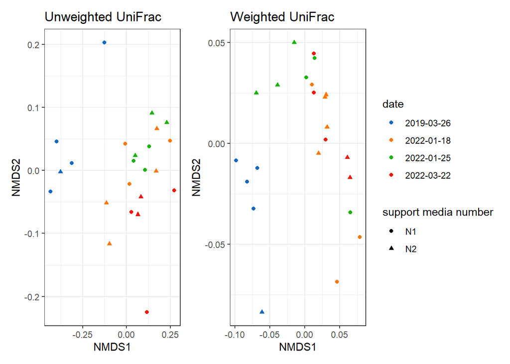

```r
library(patchwork)

uw_min5300_noChlorMitoUnassigned + w_min5300_noChlorMitoUnassigned +
  plot_layout(guides = "collect")
```

Create and download an svg image file of the plot

```r
svg('uw_w_min5300_noChlorMitoUnassigned.svg')

library(patchwork)

uw_min5300_noChlorMitoUnassigned + w_min5300_noChlorMitoUnassigned +
  plot_layout(guides = "collect")

dev.off()
```

### TAXONOMY BAR PLOTS

Load packages

```r
library(mia)
library(miaViz)
library(ggraph)
```

Prepare taxonomy bar plot of the top 20 phyla in ‘min5300_noChlorMitoUnassigned’

Get top 20 phyla from ‘min5300_noChlorMitoUnassigned’

```r
min5300_noChlorMitoUnassigned_phy <- agglomerateByRank(min5300_noChlorMitoUnassigned, rank ="Phylum", onRankOnly=TRUE)

min5300_noChlorMitoUnassigned_phy_top_20 <- getTopTaxa(min5300_noChlorMitoUnassigned_phy, top = 20, assay.type = "relabundance")
```

Look at top 20 phyla.

```r
min5300_noChlorMitoUnassigned_phy_top_20
```

```
##  [1] "Proteobacteria"    "Nitrospirota"      "Actinobacteriota"
##  [4] "Crenarchaeota"     "Acidobacteriota"   "Planctomycetota"
##  [7] "Bacteroidota"      "Verrucomicrobiota" "Myxococcota"
## [10] "Chloroflexi"       "Dadabacteria"      "Gemmatimonadota"
## [13] "Desulfobacterota"  "MBNT15"            "Bdellovibrionota"
## [16] "Cyanobacteria"     "Patescibacteria"   "Sumerlaeota"
## [19] "Dependentiae"      "WPS-2"
```

Rename the “Phylum” rank to keep only top 20 taxa, rename the rest of the taxa (i.e., those not in the top 20) as “All other phyla”.

```r
min5300_noChlorMitoUnassigned_phy_top_20_renamed <- lapply(rowData(min5300_noChlorMitoUnassigned_phy)$Phylum,
  function(x){if (x %in% min5300_noChlorMitoUnassigned_phy_top_20) {x} else {"All other phyla"}})
  rowData(min5300_noChlorMitoUnassigned_phy)$Phylum <- as.character(min5300_noChlorMitoUnassigned_phy_top_20_renamed)
```

Visualize the phyla plot

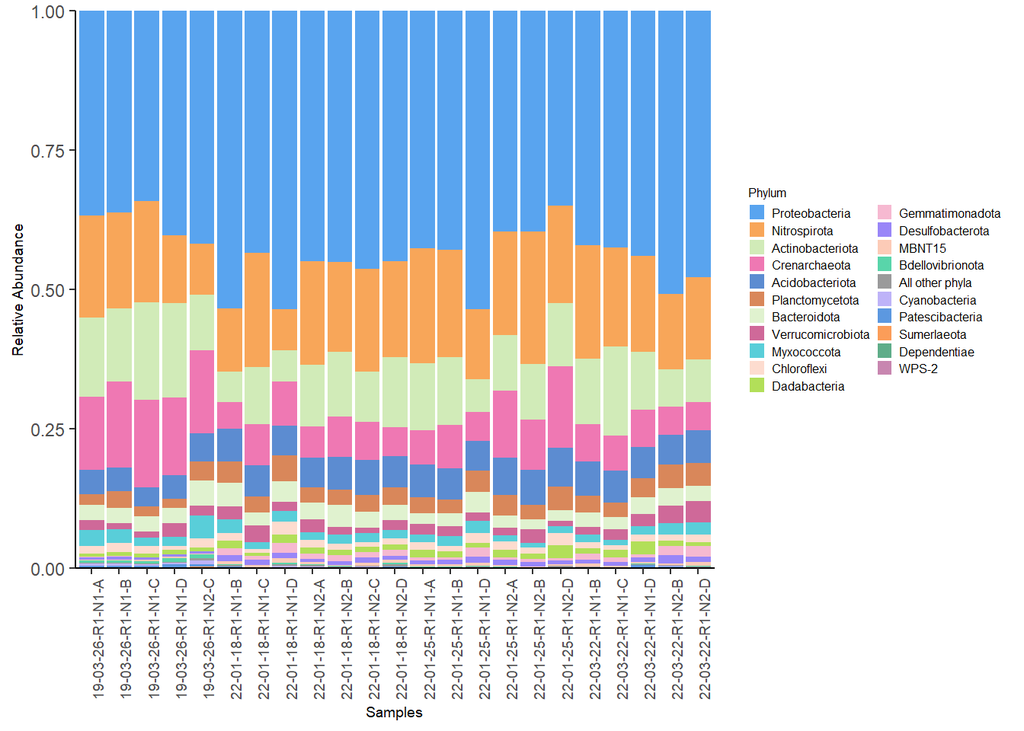

```r
plotAbundance(min5300_noChlorMitoUnassigned_phy, assay.type="counts", rank = "Phylum",
  order_rank_by="abund", order_sample_by="sampling_date",
  decreasing = FALSE, add_x_text = TRUE) +
  theme(axis.text.x = element_text(size = 7, angle = 90)) + theme(legend.position="right") +
scale_fill_manual(name = "Phylum", values = c("#0073e6", "#f57600", "#b9e192", "#e6308a", "#054fb9", "#c44601", "#cfebb6", "#b51963", "#00b4c5", "#fcc9b5", "#89ce00", "#f194b8", "#6245f5", "#faaf90", "#00bf7d", "#646466", "#9b8bf4", "#0461cf", "#F96900", "#09814A", "#AA4586")) +
theme(legend.title = element_text(size = 6), legend.text  = element_text(size = 6)) +
  theme(legend.key.size = unit(0.3, 'cm')) +
  theme(axis.title.x = element_text(size = 7)) +
  theme(axis.title.y = element_text(size = 7)) + labs(y = "Relative Abundance")
```

Prepare a taxonomy bar plot of the top 20 “named” families, with an “All other families” group that includes families not in the top 20 and “uncultured” families. Get the top 21 taxa to do this.

```r
min5300_noChlorMitoUnassigned_fam <- agglomerateByRank(min5300_noChlorMitoUnassigned, rank ="Family", onRankOnly=TRUE, remove_empty_ranks = TRUE)

min5300_noChlorMitoUnassigned_fam_top_21 <- getTopTaxa(min5300_noChlorMitoUnassigned_fam, top = 21, assay.type = "relabundance")
```

Look at families table. “uncultured” family is present (this group likely combined several diverse taxa).

```r
rowData(min5300_noChlorMitoUnassigned_fam)$Family %>% table()
```

```
## .
##                           0319-6G20                                1-20
##                                   1                                   1
##                               11-24                               67-14
##                                   1                                   1
##                                 A4b         Absconditabacteriales_(SR1)
##                                   1                                   1
##                    Acetobacteraceae                     Acetobacterales
##                                   1                                   1
##                Acidithiobacillaceae                    Alteromonadaceae
##                                   1                                   1
##                        Amb-16S-1323                     Amoebophilaceae
##                                   1                                   1
##                     Arcobacteraceae       Azospirillales_Incertae_Sedis
##                                   1                                   1
##                         Bacillaceae                  Bacteriovoracaceae
##                                   1                                   1
##            BD2-11_terrestrial_group                              BD7-11
##                                   1                                   1
##                  Bdellovibrionaceae                    Beijerinckiaceae
##                                   1                                   1
##                             BIrii41                   Blastocatellaceae
##                                   1                                   1
##                             Blfdi19                     Bryobacteraceae
##                                   1                                   1
##                    Burkholderiaceae                  Caenarcaniphilales
##                                   1                                   1
##                      Caldilineaceae          Candidatus_Abawacabacteria
##                                   1                                   1
##             Candidatus_Azambacteria         Candidatus_Campbellbacteria
##                                   1                                   1
##           Candidatus_Kaiserbacteria            Candidatus_Moranbacteria
##                                   1                                   1
##           Candidatus_Nomurabacteria             Candidatus_Peribacteria
##                                   1                                   1
##              Candidatus_Uhrbacteria                    Caulobacteraceae
##                                   1                                   1
##                              CCM11a                              CCM19a
##                                   1                                   1
##                    Chitinophagaceae                       Chlamydiaceae
```

[output cut: 144 more lines]

```
##                                   1                                   1
##                            UBA12409                          uncultured
##                                   1                                   1
##                      Unknown_Family                 Vampirovibrionaceae
##                                   1                                   1
##                  Vampirovibrionales                      Vermiphilaceae
##                                   1                                   1
##                 Verrucomicrobiaceae                           VHS-B3-70
##                                   1                                   1
##                 Vicinamibacteraceae                               WPS-2
##                                   1                                   1
##                   Xanthobacteraceae                    Xanthomonadaceae
##                                   1                                   1
##                        Yersiniaceae
##                                   1
```

Look at top 21 families. “uncultured” is in the top 21, will group with “All other families” and show the other top 20 “named” families.

```r
min5300_noChlorMitoUnassigned_fam_top_21
```

```
##  [1] "Nitrospiraceae"         "Nitrososphaeraceae"     "uncultured"
##  [4] "Nitrosomonadaceae"      "Pseudonocardiaceae"     "Hyphomicrobiaceae"
##  [7] "Parvularculaceae"       "Steroidobacteraceae"    "Saprospiraceae"
## [10] "Rhodocyclaceae"         "Methyloligellaceae"     "Thermoanaerobaculaceae"
## [13] "Amb-16S-1323"           "Blastocatellaceae"      "Nocardioidaceae"
## [16] "Comamonadaceae"         "Acetobacteraceae"       "Ga0077536"
## [19] "OM190"                  "67-14"                  "Dadabacteriales"
```

Rename the “uncultured” family as “All other families”.

```r
min5300_noChlorMitoUnassigned_fam_top_21 <- ifelse(min5300_noChlorMitoUnassigned_fam_top_21 == "uncultured", "All other families", min5300_noChlorMitoUnassigned_fam_top_21)
```

Check that “uncultured” was relabeled as “All other families”.

```r
min5300_noChlorMitoUnassigned_fam_top_21
```

```
##  [1] "Nitrospiraceae"         "Nitrososphaeraceae"     "All other families"
##  [4] "Nitrosomonadaceae"      "Pseudonocardiaceae"     "Hyphomicrobiaceae"
##  [7] "Parvularculaceae"       "Steroidobacteraceae"    "Saprospiraceae"
## [10] "Rhodocyclaceae"         "Methyloligellaceae"     "Thermoanaerobaculaceae"
## [13] "Amb-16S-1323"           "Blastocatellaceae"      "Nocardioidaceae"
## [16] "Comamonadaceae"         "Acetobacteraceae"       "Ga0077536"
## [19] "OM190"                  "67-14"                  "Dadabacteriales"
```

Rename the “Family” rank to keep only top 20 “named” taxa, rename the rest of the taxa (i.e., those not in the top 20) as “All other families”. “All other families should now include the”uncultured” families.

```r
min5300_noChlorMitoUnassigned_fam_top_21_renamed <- lapply(rowData(min5300_noChlorMitoUnassigned_fam)$Family,
  function(x){if (x %in% min5300_noChlorMitoUnassigned_fam_top_21) {x} else {"All other families"}})
  rowData(min5300_noChlorMitoUnassigned_fam)$Family <- as.character(min5300_noChlorMitoUnassigned_fam_top_21_renamed)
```

Look at renamed families table. 20 “named” taxa, with “uncultured” families and families not in the top 20 grouped in “All other families”.

```r
rowData(min5300_noChlorMitoUnassigned_fam)$Family %>% table()
```

```
## .
##                  67-14       Acetobacteraceae     All other families
##                      1                      1                    177
##           Amb-16S-1323      Blastocatellaceae         Comamonadaceae
##                      1                      1                      1
##        Dadabacteriales              Ga0077536      Hyphomicrobiaceae
##                      1                      1                      1
##     Methyloligellaceae      Nitrosomonadaceae     Nitrososphaeraceae
##                      1                      1                      1
##         Nitrospiraceae        Nocardioidaceae                  OM190
##                      1                      1                      1
##       Parvularculaceae     Pseudonocardiaceae         Rhodocyclaceae
##                      1                      1                      1
##         Saprospiraceae    Steroidobacteraceae Thermoanaerobaculaceae
##                      1                      1                      1
```

Visualize the families plot

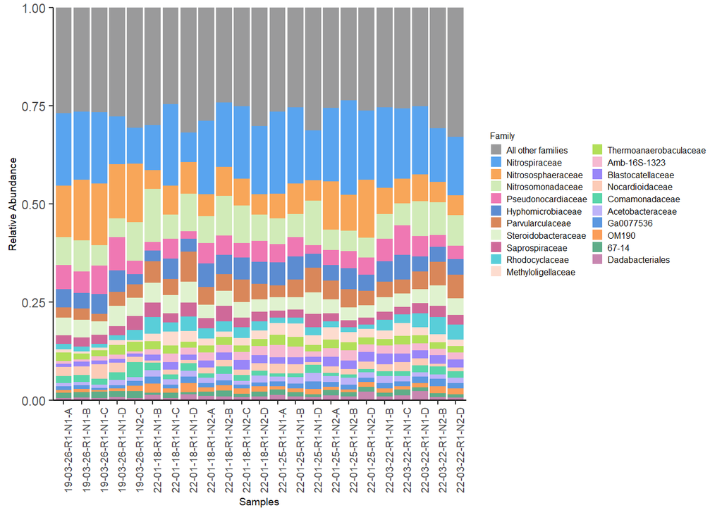

```r
plotAbundance(min5300_noChlorMitoUnassigned_fam, assay.type="counts", rank = "Family",
  order_rank_by="abund", order_sample_by="sampling_date",
  decreasing = FALSE, add_x_text = TRUE) +
  theme(axis.text.x = element_text(size = 7, angle = 90)) + theme(legend.position="right") + scale_fill_manual(name = "Family", values = c("#646466","#0073e6", "#f57600", "#b9e192", "#e6308a", "#054fb9", "#c44601", "#cfebb6", "#b51963", "#00b4c5", "#fcc9b5", "#89ce00", "#f194b8", "#6245f5", "#faaf90", "#00bf7d", "#9b8bf4", "#0461cf", "#F96900", "#09814A", "#AA4586")) +
  theme(legend.title = element_text(size = 6), legend.text  = element_text(size = 6)) +
  theme(legend.key.size = unit(0.3, 'cm')) +
  theme(axis.title.x = element_text(size = 7)) +
  theme(axis.title.y = element_text(size = 7)) + labs(y = "Relative Abundance")
```

Create and download an svg image file of the plot

```r
svg('min5300_noChlorMitoUnassigned_fam_EDIT.svg')

plotAbundance(min5300_noChlorMitoUnassigned_fam, assay.type="counts", rank = "Family",
  order_rank_by="abund", order_sample_by="sampling_date",
  decreasing = FALSE, add_x_text = TRUE) +
  theme(axis.text.x = element_text(size = 7, angle = 90)) + theme(legend.position="right") + scale_fill_manual(name = "Family", values = c("#646466","#0073e6", "#f57600", "#b9e192", "#e6308a", "#054fb9", "#c44601", "#cfebb6", "#b51963", "#00b4c5", "#fcc9b5", "#89ce00", "#f194b8", "#6245f5", "#faaf90", "#00bf7d", "#9b8bf4", "#0461cf", "#F96900", "#09814A", "#AA4586")) +
  theme(legend.title = element_text(size = 6), legend.text  = element_text(size = 6)) +
  theme(legend.key.size = unit(0.3, 'cm')) +
  theme(axis.title.x = element_text(size = 7)) +
  theme(axis.title.y = element_text(size = 7)) + labs(y = "Relative Abundance")
dev.off()
```

Save phyla and family plots

```r
min5300_noChlorMitoUnassigned_phy_20_bar <- plotAbundance(min5300_noChlorMitoUnassigned_phy, assay.type="counts", rank = "Phylum",
  order_rank_by="abund", order_sample_by="sampling_date",
  decreasing = FALSE, add_x_text = TRUE) +
  theme(axis.text.x = element_text(size = 7, angle = 90)) + theme(legend.position="right") +
scale_fill_manual(name = "Phylum", values = c("#0073e6", "#f57600", "#b9e192", "#e6308a", "#054fb9", "#c44601", "#cfebb6", "#b51963", "#00b4c5", "#fcc9b5", "#89ce00", "#f194b8", "#6245f5", "#faaf90", "#00bf7d", "#646466", "#9b8bf4", "#0461cf", "#F96900", "#09814A", "#AA4586")) +
theme(legend.title = element_text(size = 6), legend.text  = element_text(size = 6)) +
  theme(legend.key.size = unit(0.3, 'cm')) +
  theme(axis.title.x = element_text(size = 7)) +
  theme(axis.title.y = element_text(size = 7)) + labs(y = "Relative Abundance")
min5300_noChlorMitoUnassigned_fam_EDIT_20_bar <- plotAbundance(min5300_noChlorMitoUnassigned_fam, assay.type="counts", rank = "Family",
  order_rank_by="abund", order_sample_by="sampling_date",
  decreasing = FALSE, add_x_text = TRUE) +
  theme(axis.text.x = element_text(size = 7, angle = 90)) + theme(legend.position="right") + scale_fill_manual(name = "Family", values = c("#646466","#0073e6", "#f57600", "#b9e192", "#e6308a", "#054fb9", "#c44601", "#cfebb6", "#b51963", "#00b4c5", "#fcc9b5", "#89ce00", "#f194b8", "#6245f5", "#faaf90", "#00bf7d", "#9b8bf4", "#0461cf", "#F96900", "#09814A", "#AA4586")) +
  theme(legend.title = element_text(size = 6), legend.text  = element_text(size = 6)) +
  theme(legend.key.size = unit(0.3, 'cm')) +
  theme(axis.title.x = element_text(size = 7)) +
  theme(axis.title.y = element_text(size = 7)) + labs(y = "Relative Abundance")
```

Combine plots

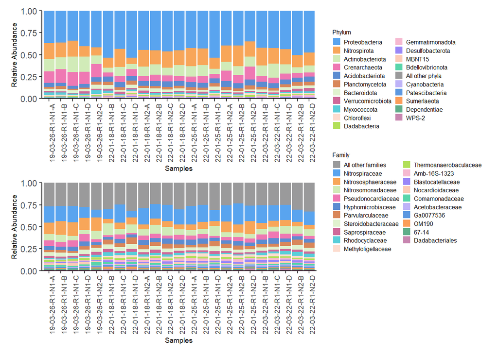

```r
library(patchwork)
((min5300_noChlorMitoUnassigned_phy_20_bar) / (min5300_noChlorMitoUnassigned_fam_EDIT_20_bar)) +
  plot_layout(guides = "collect")
```

```r
# Create and download an svg image file of the plot
svg('min5300_noChlorMitoUnassigned_phy_fam_EDIT_20_bar.svg')
((min5300_noChlorMitoUnassigned_phy_20_bar) / (min5300_noChlorMitoUnassigned_fam_EDIT_20_bar)) +
  plot_layout(guides = "collect")

dev.off()
```